# “WeRateDogs Exploratory Data Analysis”

Nawal YALA

> In this work I will present an analyse and vizualization of the tweet archive of Twitter user @dog_rates, also known as WeRateDogs. WeRateDogs is a Twitter account that rates people’s dogs with a humorous comment about the dog. These ratings almost always have a denominator of 10. The numerators, though? Almost always greater than 10. 11/10, 12/10, 13/10, etc. Why? Because “they’re good dogs Brent.” WeRateDogs has over 4 million followers and has received international media coverage. To more detail about this data, its structure and variables, please see the wrangling process that I have done on it in the same directory.

Overview on WeRateDogs tweet dataset and its structure

```
## 'data.frame':    5922 obs. of  16 variables:
##  $ tweet_id      : num  8.92e+17 8.92e+17 8.92e+17 8.92e+17 8.92e+17 ...
##  $ timestamp     : Factor w/ 1970 levels "2015-11-15 22:32:08",..: 1970 1970 1970 1969 1969 1969 1968 1968 1968 1967 ...
##  $ source        : Factor w/ 3 levels "TweetDeck","Twitter for iPhone",..: 2 2 2 2 2 2 2 2 2 2 ...
##  $ text          : Factor w/ 1970 levels "\"AND IIIIIIIIIIIEIIIIIIIIIIIII WILL ALWAYS LOVE YOUUUUU\" 11/10 https://t.co/rSNCEiTtfI",..: 1549 1549 1549 1743 1743 1743 811 811 811 1051 ...
##  $ expanded_urls : Factor w/ 1970 levels "http://goo.gl/ArWZfi,https://twitter.com/dog_rates/status/709901256215666688/photo/1,https://twitter.com/dog_ra"| __truncated__,..: 1947 1947 1947 1946 1946 1946 1945 1945 1945 1944 ...
##  $ name          : Factor w/ 914 levels "Abby","Ace","Acro",..: 662 662 662 844 844 844 32 32 32 230 ...
##  $ stage         : Factor w/ 5 levels "doggo","floofer",..: 3 3 3 3 3 3 3 3 3 3 ...
##  $ Rating        : num  1.3 1.3 1.3 1.3 1.3 1.3 1.2 1.2 1.2 1.3 ...
##  $ retweet_count : int  8345 8345 8345 6166 6166 6166 4079 4079 4079 8488 ...
##  $ favorite_count: int  38136 38136 38136 32715 32715 32715 24629 24629 24629 41487 ...
##  $ jpg_url       : Factor w/ 1970 levels "https://pbs.twimg.com/ext_tw_video_thumb/674805331965399040/pu/img/-7bw8niVrgIkLKOW.jpg",..: 1967 1967 1967 1966 1966 1966 1965 1965 1965 1947 ...
##  $ img_num       : int  1 1 1 1 1 1 1 1 1 1 ...
##  $ pred_algo     : Factor w/ 3 levels "algo1","algo2",..: 1 2 3 1 2 3 1 2 3 1 ...
##  $ img_pred      : Factor w/ 626 levels "abaya","academic_gown",..: 384 29 35 127 410 401 127 339 300 400 ...
##  $ pred_coef     : num  0.097 0.0859 0.0761 0.3236 0.0906 ...
##  $ is_a_dog      : Factor w/ 2 levels "False","True": 1 1 1 2 2 2 2 2 2 1 ...
```

```r
rt$jpg_url <- toString(rt$jpg_url)
```

# Univariate Plots Section

Question: What the most utility used by WeRateDogs to post tweets

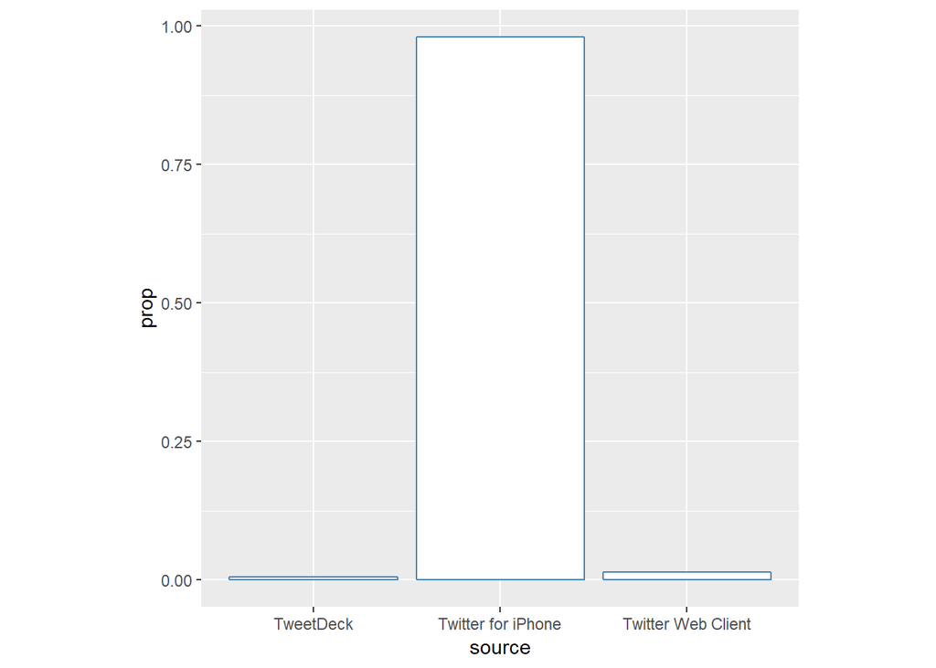

Question: How i the evolution of tweet number across year

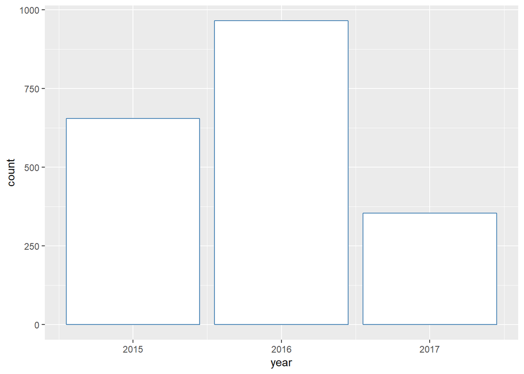

Question: What is the most popular tweet?

First we get the max favorite_count / retweet_count

```
##    Min. 1st Qu.  Median    Mean 3rd Qu.    Max.
##      80    1913    3990    8831   10981  164649
```

Then we extract the tweet text and the dog image

```
##                                                                                                                  text
## 1 Here's a doggo realizing you can stand in a pool. 13/10 enlightened af (vid by Tina Conrad) https://t.co/7wE9LTEXC4
```

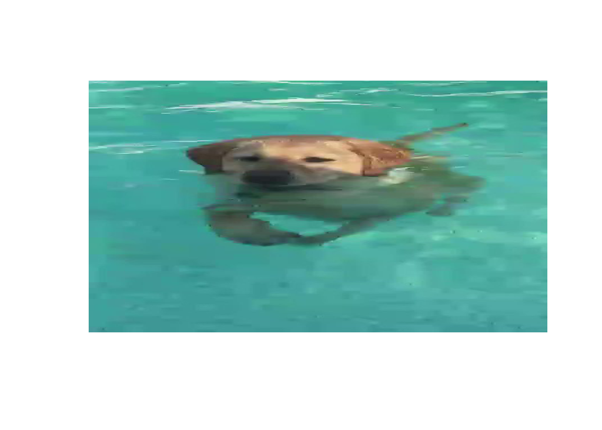

Question: Which dog has the higher rating value?

```
##    Min. 1st Qu.  Median    Mean 3rd Qu.    Max.    NA's
##   0.000   1.000   1.100   1.169   1.200 177.600       3
```

```
##                                                                             text
## 1 This is Atticus. He's quite simply America af. 1776/10 https://t.co/GRXwMxLBkh
```

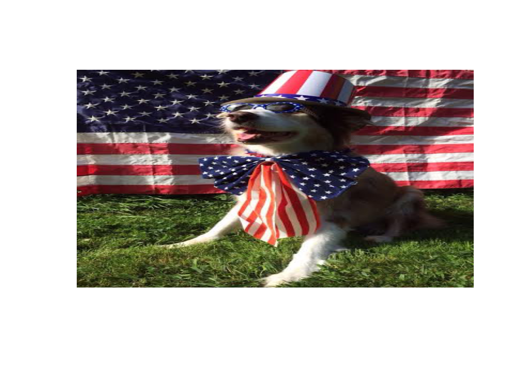

Question: How is the distribution of favorite_count and retweet_count variables?

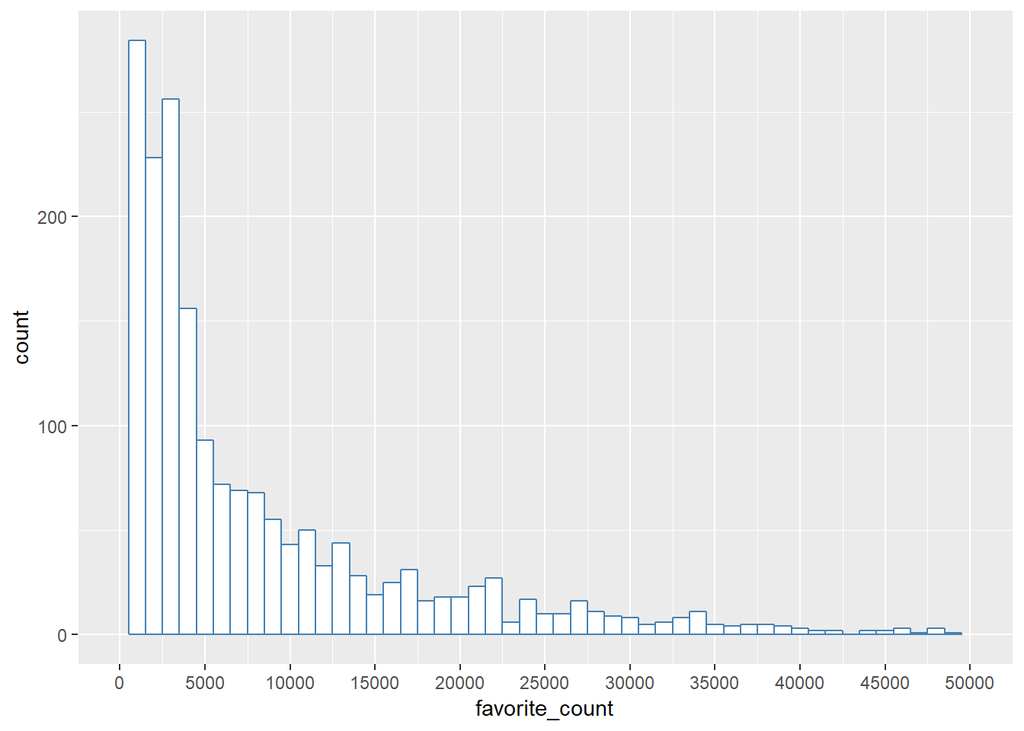

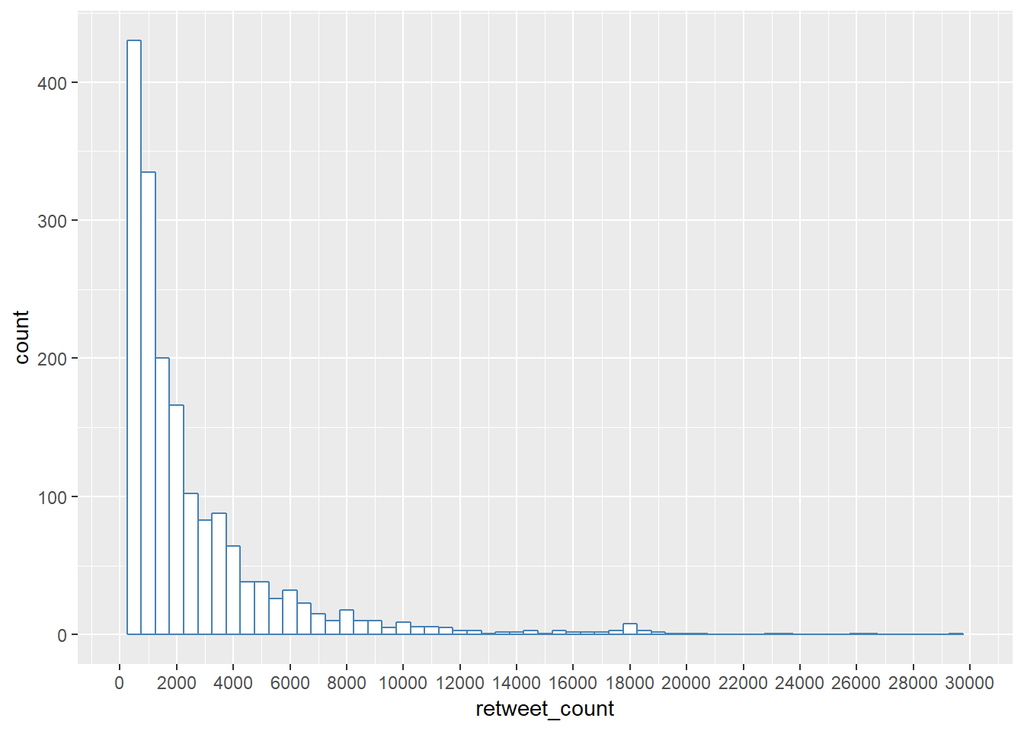

Tweets are more favorited thant retweeted.

Question: How is the distribution of dog rating values.

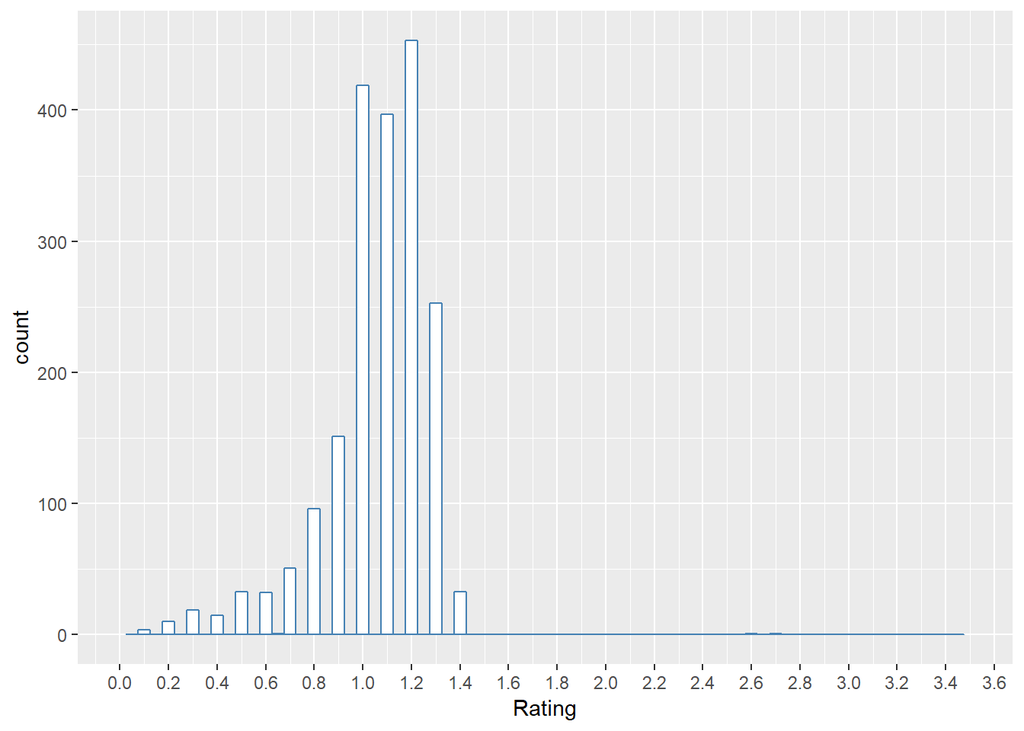

Almost normal distribution

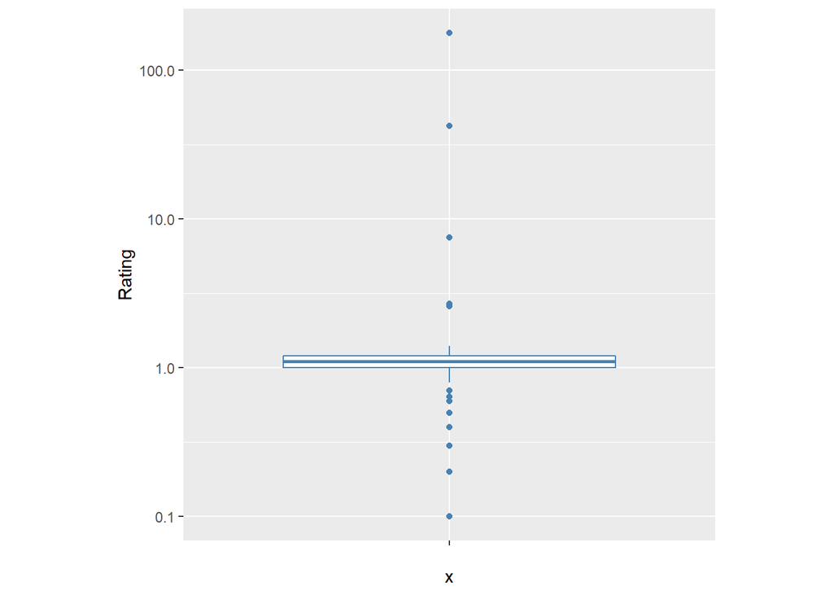

Many outliers. Median Rating values is just over 1 (boxplot) and mean is around 1 also (histogram).

Question: Each dog image in the WeRateDogs tweet dataset is passed to 3 different pattern recognition algorithms. Let’s know how each algorithm was accurate

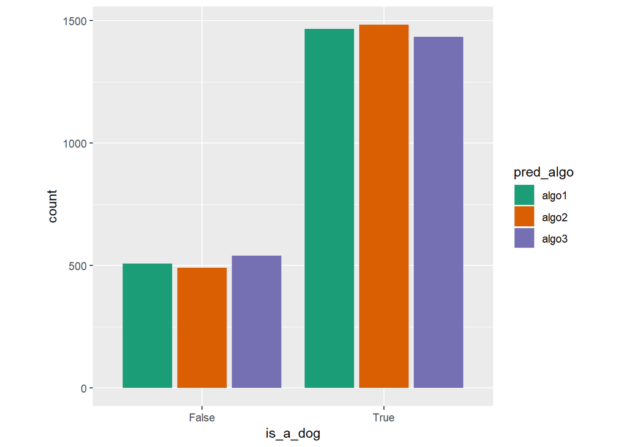

algo2 is the most accurate algorithm.

Question: What were the dog stages?

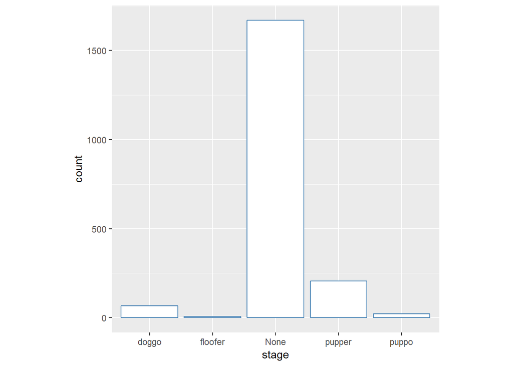

Most dogs are not given a satge.

# Bivariate Plots Section

Let’s know which dog stage has higer reating value.

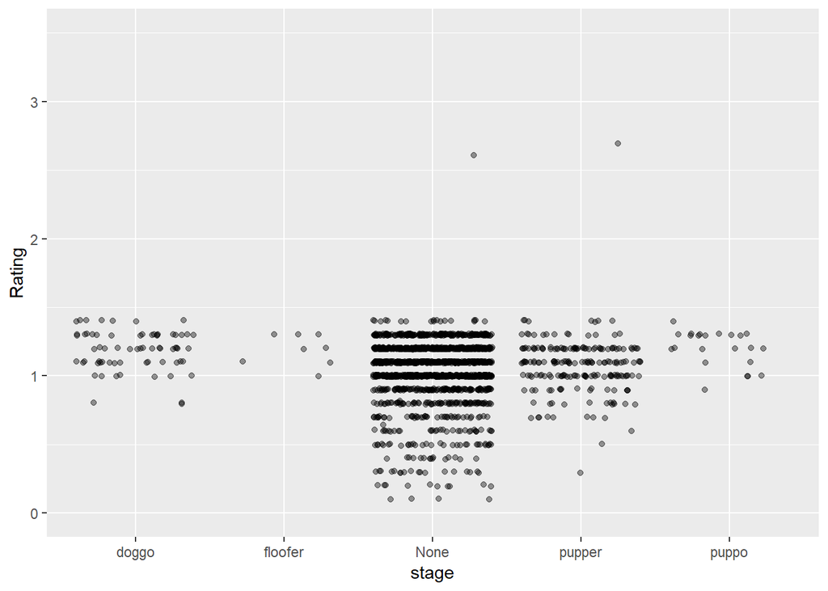

# Reference:

[how to download and display an image from an URL in R?](https://stackoverflow.com/questions/29110903/how-to-download-and-display-an-image-from-an-url-in-r)

[Convert a list into a string (for a url)](https://stackoverflow.com/questions/30861769/convert-a-list-into-a-string)